# Covid-19 state in Romania

W.A.Dishilki Jayarathne

10/4/2022

## Romania

Romania is a country located at the crossroads of Central, Eastern, and Southeastern Europe. It borders Bulgaria to the south, Ukraine to the north, Hungary to the west, Serbia to the southwest, Moldova to the east, and the Black Sea to the southeast. It has a predominantly temperate-continental climate, and an area of 238,397 km2 (92,046 sq mi), with a population of around 19 million. Romania is the twelfth-largest country in Europe and the sixth-most populous member state of the European Union. Its capital and largest city is Bucharest.

https://en.wikipedia.org/wiki/Romania#:~:text=Romania%20is%20the%20twelfth%2Dlargest,Romania.

## About Helthcare in Romania

Romania regularly falls around last place in the European Health Consumer Index. It has an underfunded and inefficient system.Romania has a program of universal health insurance. There is a mandatory payroll tax which the country uses to provide coverage to the entire population. Romania consistently spends around 4% of its GDP on healthcare, which is one of the lowest rates in the E.U. In addition to health insurance, the government also operates a majority of the hospitals in the country, many of which are aging and chronically underfunded. The country has built very few new hospitals since the end of communism. While Romania has opened the door to private insurance and hospitals over the past few decades, they have yet to take off. There is an acute shortage of healthcare professionals in the country,with around 30% of positions unfilled.

Acoding to https://www.frontiersin.org/articles/10.3389/fpubh.2021.813941/full article, During the first few months, the vaccination campaign progressed as planned, but then it stalled. By the surge of the fourth wave, only ≈30% of Romanians were fully immunized, one of the lowest COVID-19 vaccination coverages in Europe, and the main reason for this epidemiological crisis

https://borgenproject.org/healthcare-in-romania/

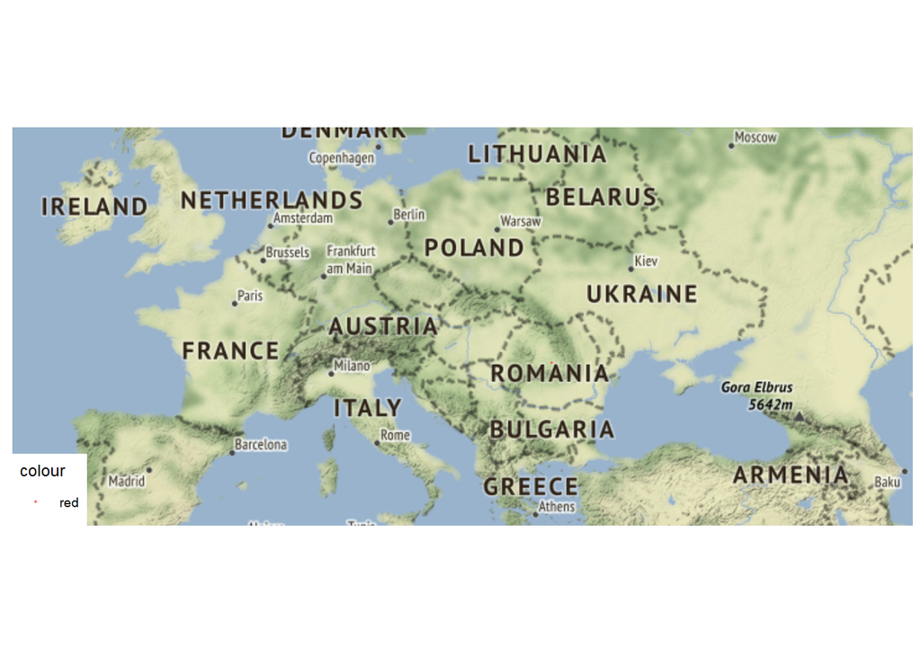